# Distribución del Ingreso y Visualización

Seminario Estadística y programación para estudios del trabajo, desigualdad y pobreza

DOCENTES:

Guido Weksler

Santiago Poy

```r
library(tidyverse)
library(readxl)
library(lubridate)      # Para manejar fechas
library(plotly)         # Gráficos interactivos
library(ggthemes)       # temas
```

# Carga de informacion

```r
individual_25_t1 <-
  read.table("../bases_eph/usu_individual_T125.txt",
  sep = ";",
  dec = ",",
  header = TRUE,
  fill = TRUE )
```

# Ingresos en la EPH

## Armado de quintiles

Dadas las características de la EPH, el armado de percentiles asociados a variables de ingreso (de individuos o familias) requiere tener en cuenta dos aspectos importantes:  
- Debemos perturbar aleatoriamente la variable de ingresos en cuestión (dado que se acumulan muchos casos en valores puntuales. La gente declara ingresos redondeando lo que percibe realmente).  
- Necesitamos utilizar una función que permita incorporar ponderadores al armado de los percentiles. Utilizaremos el paquete statar.

## Funciones para perturbar una variable

Veamos la función `runif()` para *randomizar* números con una distribución uniforme, entre un mínimo y máximo establecido.

```r
runif(n = 10,min = -0.99,max = 0.99) # Randomización de numeros basada en una distribución uniforme entre "min y max"
```

```
 [1] -0.032420266 -0.623933043 -0.880791298 -0.628379972  0.006542091
 [6] -0.914138079 -0.315922175  0.793600121 -0.121540873 -0.801903064
```

¿Qué pasa si lo volvemos a correr la misma función de *aleatorización*?

```r
runif(n = 10,min = -0.99,max = 0.99)
```

```
 [1]  0.91671054 -0.86989292  0.24454510 -0.02038819 -0.76925060  0.59956412
 [7]  0.88164735 -0.64865326  0.76425823  0.20885833
```

Al volver a ejecutarla podemos obtener resultados distintos a los previos. Para garantizar replicabilidad del ejercicio, podemos utilizar la función `set.seed()`. Esta función nos permite, a partir de especificarle un número cualquiera, garantizar los mismos resultados cada vez que ejecutemos luego una función que realiza un procedimiento aleatorio

```r
set.seed(9999) #Semilla
runif(10,min = 0.01,max = 0.99)
```

```
 [1] 0.8536228 0.6570367 0.7944079 0.2134931 0.6856946 0.8379731 0.2253613
 [8] 0.8118359 0.9881936 0.7358825
```

```r
set.seed(9999) #Semilla
runif(10,min = 0.01,max = 0.99)
```

```
 [1] 0.8536228 0.6570367 0.7944079 0.2134931 0.6856946 0.8379731 0.2253613
 [8] 0.8118359 0.9881936 0.7358825
```

Para continuar con el ejercicio, lo que hacemos es:

- Transformar en numérica la variable PONDIIO (La variable se carga como integer, y necesita ser numerica para evitar un error llamado integer overflow).
- Setear la semilla antes del pedazo de código en el cual vamos a sumarle a la variable **P21** una variable de números aleatorios con distribución uniforme. La variable que se suma a P21, debe tener la misma longitud que aquella, lo cual podemos lograr especificando `nrow(.)` dentro de nuestra estructura de prodcesamiento sucesivo.
- Luego, a partir de la variable perturbada *P21_p* podemos crear los quintiles con la función `xtile()` que corresponde al paquete **statar**.
- Una vez que tenemos una base con los quintiles, podemos agrupar por dicha variable y generar todos los indicadores que nos resulten útiles para analizar.

```r
set.seed(9999) #Semilla
base_con_quintiles <- individual_25_t1 %>%
  mutate(PONDIIO = as.numeric(PONDIIO)) %>% # Para evitar Integer Overflow
  filter(P21 > 0) %>%
  mutate(P21_p  = P21 + runif(nrow(.),
                              min = -0.99,
                              max = 0.99)) %>%
  mutate(quintil = statar::xtile(x = P21_p,
                         n = 5,
                         wt = PONDIIO))

resultado <- base_con_quintiles %>%
  group_by(quintil) %>%
  summarise(casos = n(),
            casos_pondera = sum(PONDIIO),
            tasa_feminizacion = sum(PONDIIO[CH04==2])/casos_pondera,
            salario_prom = weighted.mean(x = P21,w = PONDIIO))
```

```r
resultado
```

```
# A tibble: 5 × 5
  quintil casos casos_pondera tasa_feminizacion salario_prom
    <int> <int>         <dbl>             <dbl>        <dbl>
1       1  3390       2586837             0.614      168252.
2       2  3585       2586945             0.496      415672.
3       3  3323       2585482             0.413      665178.
4       4  2916       2587101             0.348      918962.
5       5  2588       2585441             0.306     1904128.
```

# Introducción a la visualización

Una parte importante del uso de R consiste en las herramientas de visualización que este provee. Para ello, a partir de aquí trabajaremos sobre la librería `ggplot`. la cual forma parte del entorno `tidyverse` y su uso se encuentra ampliamente difundido entre la comunidad de usuarios/as de R.

Para comenzar, además de analizar a la estructura de la lógica sintáctica, trabajaremos sobre un concepto central de `ggplot` que es la asignaciòn de atributos estéticos a los valores que toma una determinada variable. Dicho de otra forma, como mostrar de modo perceptible a la vista la diferencia entre valores: generalmente lo hacemos describiendo posiciones de un valor x y un valor y, pero también puedo definir un tamaño, una forma, o un color.

`ggplot` tiene su sintaxis propia. La idea central es pensar los gráficos como una sucesión de capas, que se construyen una a la vez.

¿Cómo funciona esto en la práctica?

- El comando `ggplot()` nos permite definir los **datos** y las **variables** (x,y,color,forma,etc).
- El operador `+` nos permite incorporar nuevas capas al gráfico.
- Las sucesivas capas nos permiten definir:
- Uno o más tipos de gráficos (de columnas, `geom_col()`, de línea, `geom_line()`, de puntos,`geom_point()`, boxplot, `geom_boxplot()`).
- Títulos `labs()`.
- Estilo del gráfico `theme()`.
- Escalas de los ejes `scale_y_continuous`, `scale_x_discrete`.
- División en subconjuntos `facet_wrap()`, `facet_grid()`.

ggplot tiene muchos comandos, y no tiene sentido saberlos de memoria, es siempre útil reutilizar gráficos viejos y tener a mano el [machete](https://posit.co/).

Para armar un gráfico, vamos a necesitar definir al menos una geometría (el recurso visual con el que vamos a mostrar la información, como líneas, puntos, barras, etc.) y al menos una asignación estética (especificar cuales variables queremos mostrar, y que atributo estético va a representar sus valores, como el color, el tamaño, la transparencia, etc.).

##### Gráfico de Puntos

A continuación vamos a crear un **dataframe** como insumo para realizar un gráfico de puntos. Visualizaremos el salario promedio y la tasa de no registro, para cada uno de los aglomerados EPH. El tamaño de los puntos estará seteado en función de la cantidad de asalariados, y el color en función de la región de pertenencia

- Cargamos una base de la EPH, y los diccionarios de regiones y aglomerados.
- Agrupamos por aglomerado (y región) y estimamos la tasa de no registro y el salario promedio

```r
aglomerados <- read_excel("../bases_eph/Aglomerados y Regiones EPH.xlsx")
regiones <- read_excel("../bases_eph/Aglomerados y Regiones EPH.xlsx",sheet = "Regiones EPH",skip = 1) # parametro skip = 1, para saltear una fila

salario_y_no_registro <- individual_25_t1 %>%
  filter(ESTADO == 1, CAT_OCUP == 3) %>%
  group_by(ANO4,TRIMESTRE,REGION,AGLOMERADO) %>%
  summarise(tasa_no_reg = sum(PONDERA[PP07H == 2])/sum(PONDERA),
            salario_prom = weighted.mean(P21,PONDIIO),
            asalariados = sum(PONDERA)) %>%
  ungroup() %>%
  left_join(aglomerados,by = c("AGLOMERADO")) %>%
  left_join(regiones,by = c("REGION"))

salario_y_no_registro
```

```
# A tibble: 32 × 9
    ANO4 TRIMESTRE REGION AGLOMERADO tasa_no_reg salario_prom asalariados
   <int>     <int>  <dbl>      <dbl>       <dbl>        <dbl>       <int>
 1  2025         1      1         32       0.219          NA      1173789
 2  2025         1      1         33       0.384          NA      4087960
 3  2025         1     40         18       0.420      508647.      132464
 4  2025         1     40         19       0.397          NA       122311
 5  2025         1     40         22       0.394      648568.       75189
 6  2025         1     40         23       0.438      702662.      196617
 7  2025         1     40         25       0.361      486518.       85934
 8  2025         1     40         29       0.508          NA       290139
 9  2025         1     41          7       0.338      657936.      111529
10  2025         1     41          8       0.385      534219.      127268
# ℹ 22 more rows
# ℹ 2 more variables: Nom_Aglo <chr>, Region <chr>
```

Aquí se muestra el gráfico final a alcanzar.

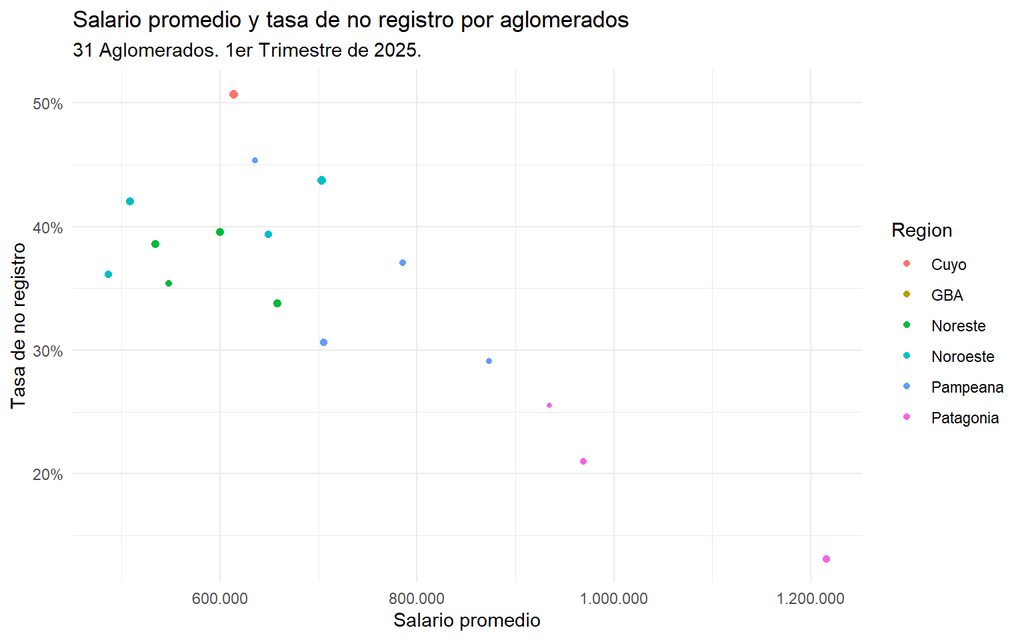

**Capas del Gráfico**

Veamos ahora, el “paso a paso” o “capa a capa” del gráfico. Dentro de `ggplot()`:

- Defino el dataframe que voy a utilizar con el parámetro `data =`
- Defino los parametros estéticos del gráfico que van a depender de las variables de mi dataframe dentro del `aes()`

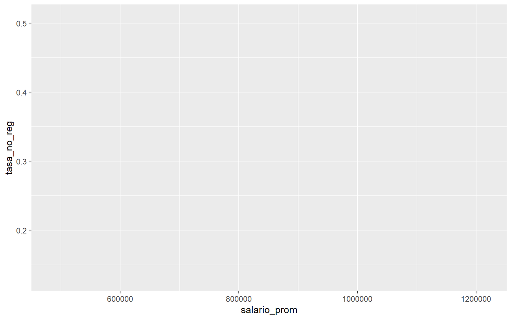

```r
capa1 <- ggplot(data = salario_y_no_registro,
                aes(x = salario_prom,
                y = tasa_no_reg,
                size = asalariados,
                color = Region))

capa1
```

- Defino el tipo de geometría de gráfico que quiero (en este caso de puntos, pero podría ser de columnas, líneas, densidad, etc)

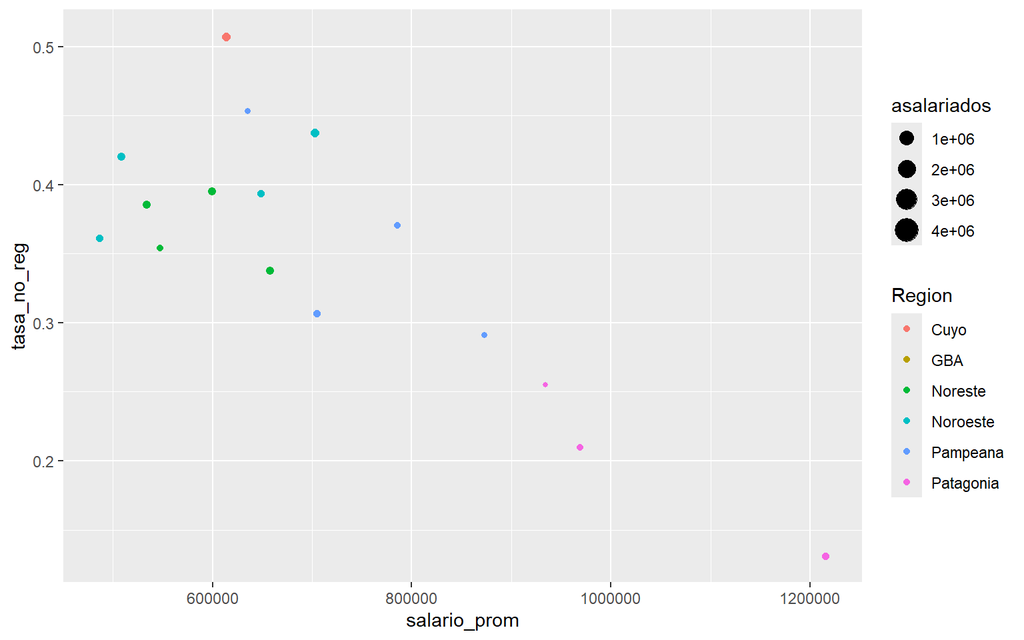

```r
capa2 <- capa1 +
  geom_point()

capa2
```

- Con la capa labs() puedo definir título, subtitulo y nombres de ejes del gráfico

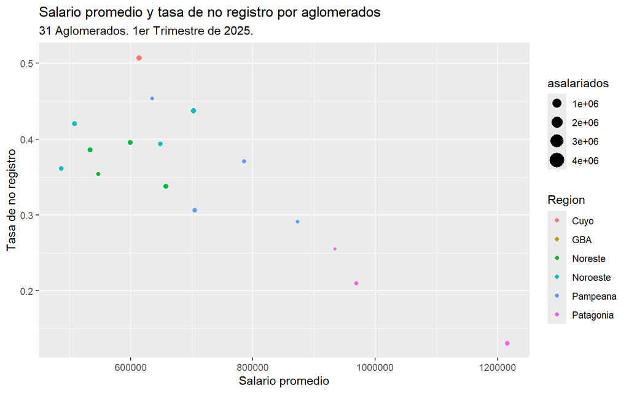

```r
capa3 <- capa2 +
  labs(title = "Salario promedio y tasa de no registro por aglomerados",
       subtitle = "31 Aglomerados. 1er Trimestre de 2025.",
       x = "Salario promedio",
       y = "Tasa de no registro")

capa3
```

- En la capa de `theme()` puedo cambiar el diseño del cuadrante donde se visualizan los datos. En este caso usé la función `theme_minimal()`del paquete **ggthemes** que tiene definido un tema con fondo blanco y pequeñas líneas grises para seguir la línea de los números que se muestran en el eje.
- En la capa de `guides()` es donde puedo modificar todo lo vinculado a las leyendas del gráfico. En este caso, lo usamos para eliminar la leyenda asociada al tamaño de los puntos. También allí podría modificar el título de la otra leyenda, el tamaño de los puntos, etc.
- Las últimas dos capas `scale_y_continuous()` y `scale_x_continuous()` me permiten modificar las escalas de los respectivos ejes, cambiar el formato en el que aparecen los números, o cuántas referencias mostrar de la escala en cuestión.

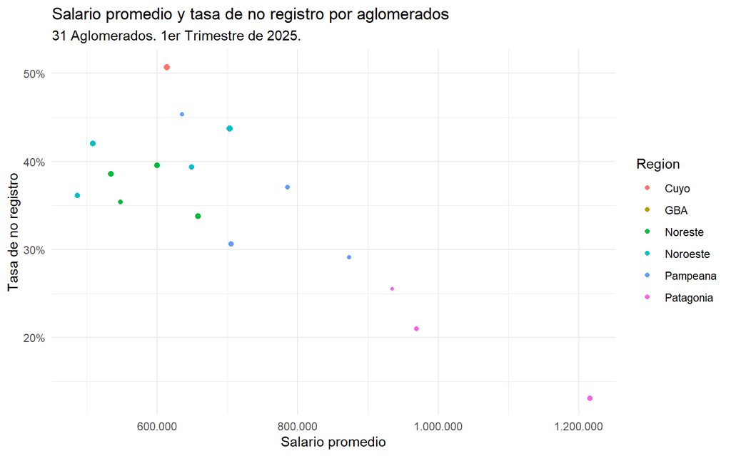

```r
grafico_final <- capa3 +
theme_minimal()+
  guides(size = FALSE)+
  scale_y_continuous(labels = scales::percent_format(accuracy = 1))+
  scale_x_continuous(labels = scales::number_format(big.mark = ".",decimal.mark = ","))


grafico_final
```

##Grabar un grafico

```r
#ggsave(filename = "Resultados/Kernel_3.png",plot = grafico_final)
```

### Extensiones de [GGplot](https://exts.ggplot2.tidyverse.org/gallery/).

La librería GGplot tiene a su vez muchas otras librerías que extienden sus potencialidades:

- [ggplotly](https://plotly.com/ggplot2/): Para hacer gráficos interactivos
- [gganimate](https://gganimate.com/): Para hacer gráficos animados.
- [ggridge](https://cran.r-project.org/web/packages/ggridges/vignettes/introduction.html): Para hacer gráficos de densidad faceteados
- [ggally](https://ggobi.github.io/ggally/): Para hacer varios gráficos juntos.
- [treemapify](https://cran.r-project.org/web/packages/treemapify/vignettes/introduction-to-treemapify.html)

#### Plotly

Con la librería plotly podemos rápidamente hacer interactivo un gráfico de ggplot. Simplemente tenemos que aplicar al función `ggplotly()` a nuestro gráfico.

En el parámetro `tooltip =` le podemos pasar que variable queremos que se muestre al pasar por la geometría del gráfico con el mouse.

```r
library(plotly)

grafico_final <- ggplot(data = salario_y_no_registro,
       aes(x = salario_prom,
       y = tasa_no_reg,
       size = asalariados,
       aglo = Nom_Aglo, #Aca creo un parametro del aes que depende de Nom_Aglo
       color = Region))+
  geom_point()+
  labs(title = "Salario promedio y tasa de no registro por aglomerados",
       subtitle = "31 Aglomerados. 1er Trimestre de 2025.",
       x = "Salario promedio",
       y = "Tasa de no registro")+
  theme_minimal()+
  guides(size = F)+
  scale_y_continuous(labels = scales::percent_format(accuracy = 1))+
  scale_x_continuous(labels = scales::number_format(big.mark = ".",decimal.mark = ","))

ggplotly(grafico_final,tooltip = "aglo")
```

[interactive chart not shown]

#### GGally

Permite visualizar rápidamente el cruce de todas las variables de un dataframe

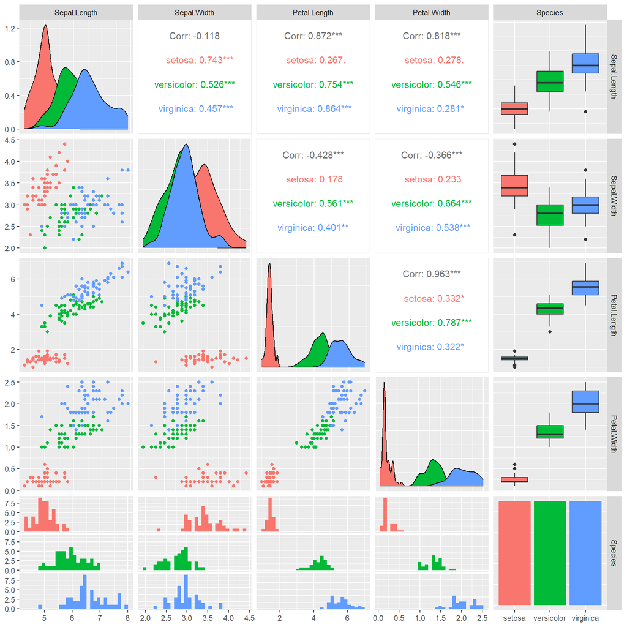

```r
library(GGally)

ggpairs(iris,  mapping = aes(color = Species))
```

## Otros ejemplos

- Creamos acá un nuevo dataframe para mostrar otros gráficos
  - sólo con los casos de ingreso de la ocupación principal mayores a 0.
  - Con una variable categórica para el sexo

```r
base_para_otros_ejemplos <- individual_25_t1 %>%
  left_join(regiones) %>%
  filter(P21>0) %>%
  mutate(Sexo = case_when(CH04 == 1 ~ "Varón",
                          CH04 == 2 ~ "Mujer"))
```

#### ggridges

Util para comparar distribuciones según distintas categorías

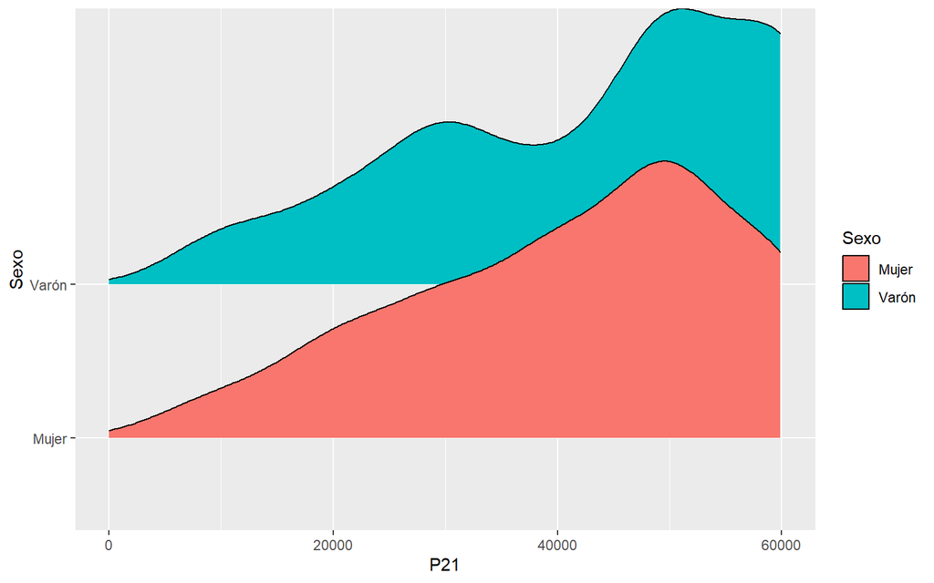

```r
library(ggridges)

ggplot(base_para_otros_ejemplos, aes(x = P21, y = Sexo, fill=Sexo)) +
  geom_density_ridges()+
  scale_x_continuous(limits = c(0,60000))#Restrinjo el gráfico hasta ingresos de $60000
```

#### Boxplot de ingresos de la ocupación principal, según región

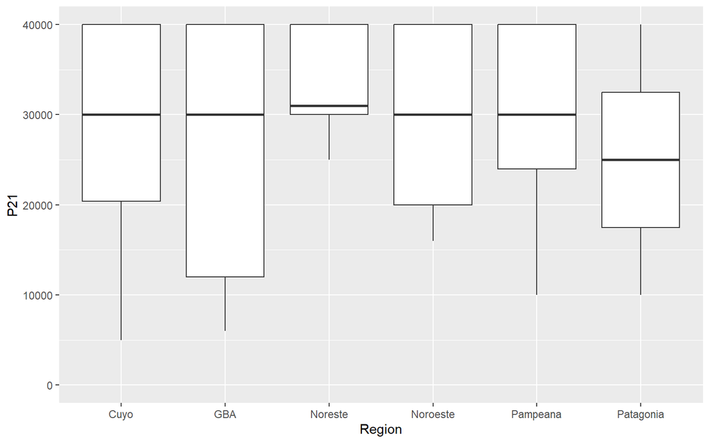

```r
ggplot(base_para_otros_ejemplos, aes(x = Region, y = P21)) +
  geom_boxplot()+
  scale_y_continuous(limits = c(0, 40000))#Restrinjo el gráfico hasta ingresos de $40000
```

Si queremos agregar la dimensión *sexo*, podemos hacer un `facet_wrap()`

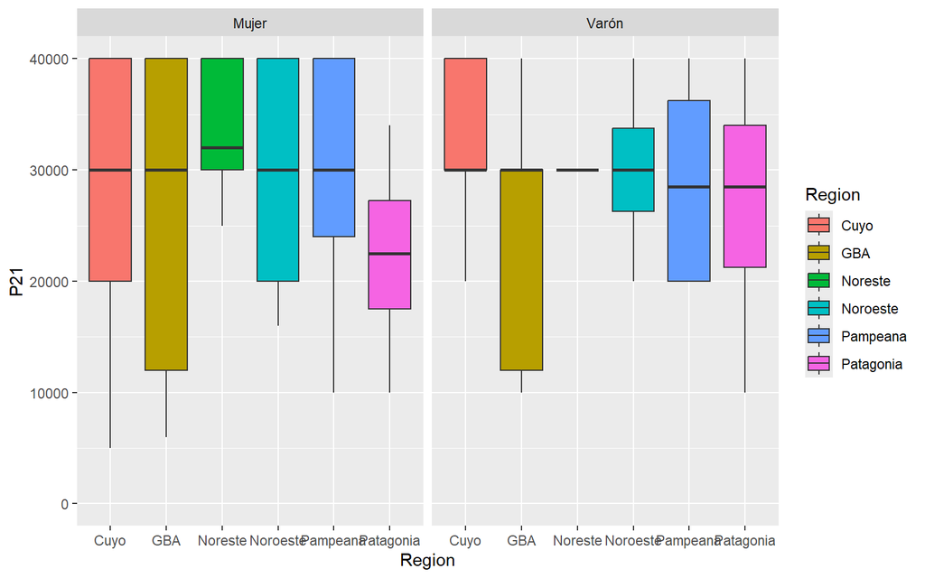

```r
ggplot(base_para_otros_ejemplos, aes(x= Region, y = P21 ,fill = Region )) +
  geom_boxplot()+
  scale_y_continuous(limits = c(0, 40000))+
  facet_wrap(vars(Sexo))
```

Por la forma en que está presentado el gráfico, el foco de atención sigue puesto en las diferencias de ingresos entre regiones. Simplemente se agrega un corte por la variable de sexo.

Si lo que queremos hacer es poner el foco de atención en las diferencias por sexo, simplemente basta con invertir la variable x especificada con la variable utilizada en el `facet_wrap`

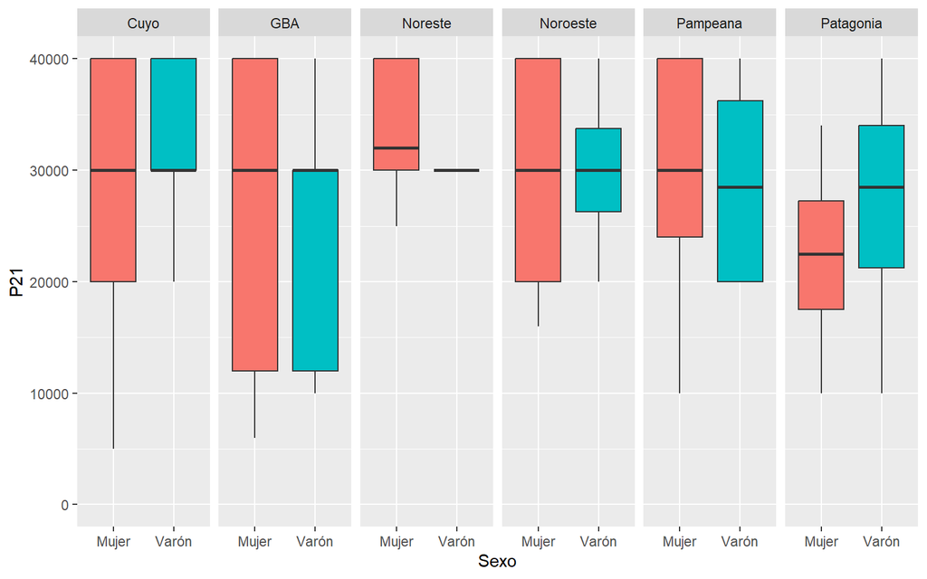

```r
ggplot(base_para_otros_ejemplos, aes(x= Sexo, y = P21, group = Sexo, fill = Sexo )) +
  geom_boxplot()+
  scale_y_continuous(limits = c(0, 40000))+
  facet_wrap(vars(Region),nrow = 1) +
  theme(legend.position = "none")
```

#### [Histogramas](https://ggplot2.tidyverse.org/reference/geom_histogram.html)

Por ejemplo, si observamos el ingreso de la ocupación principal:

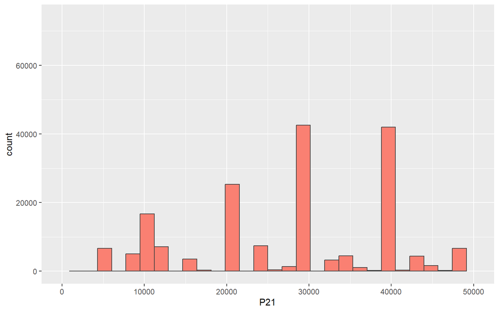

```r
ggplot(base_para_otros_ejemplos, aes(x = P21,weights = PONDIIO))+
geom_histogram(fill='salmon', color='grey25')+
scale_x_continuous(limits = c(0,50000))
```

En este gráfico, los posibles valores de p21 se dividen en 30 **bins** consecutivos y el gráfico muestra cuantas observaciones caen en cada uno de ellos

#### [Kernels](https://plot.ly/ggplot2/geom_density/)

La función `geom_density()` nos permite construir **kernels** de la distribución. Es particularmente útil cuando tenemos una variable continua, dado que los histogramas rompen esa sensación de continuidad.

Veamos un ejemplo sencillo con los ingresos de la ocupación principal. Luego iremos complejizandolo

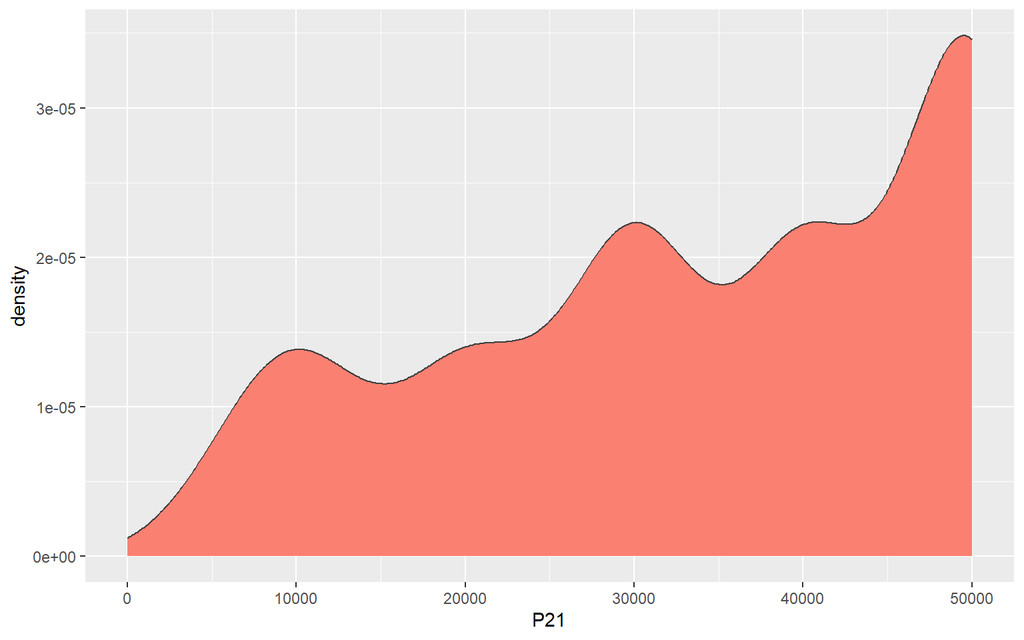

```r
ggplot(base_para_otros_ejemplos, aes(x = P21,weights = PONDIIO))+
geom_density(fill='salmon', color='grey25')+
scale_x_continuous(limits = c(0,50000))
```

**El eje y no tiene demasiada interpretabilidad en los Kernel, porque hace a la forma en que se construyen las distribuciones**.

El parametro adjust, dentro de la función `geom_density`nos permite reducir o ampliar el rango de suavizado de la distribución. Su valor por default es 1. Veamos que sucede si lo seteamos en 2

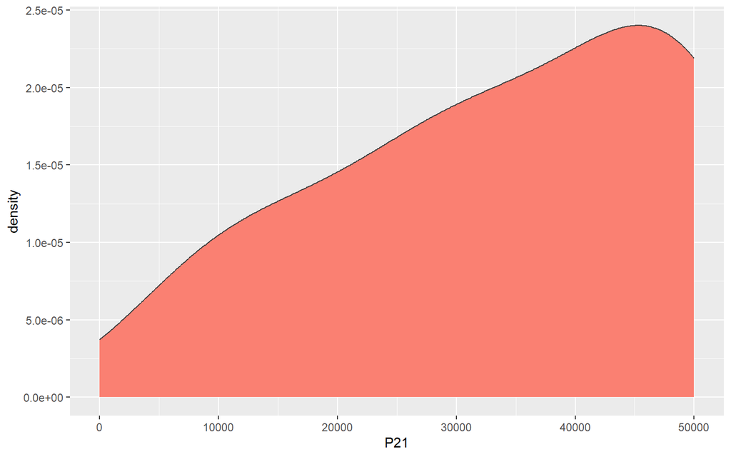

```r
ggplot(base_para_otros_ejemplos, aes(x = P21,weights = PONDIIO))+
geom_density(adjust = 2,fill='salmon', color='grey25')+
scale_x_continuous(limits = c(0,50000))
```

Como es esperable, la distribución del ingreso tiene “picos” en los valores redondos, ya que la gente suele declarar un valor aproximado al ingreso efectivo que percibe. Nadie declara ingresos de 30001. Al suavizar la serie con un kernel, eliminamos ese efecto.Si seteamos el rango para el suavizado en valores menores a 1, podemos observar estos picos.

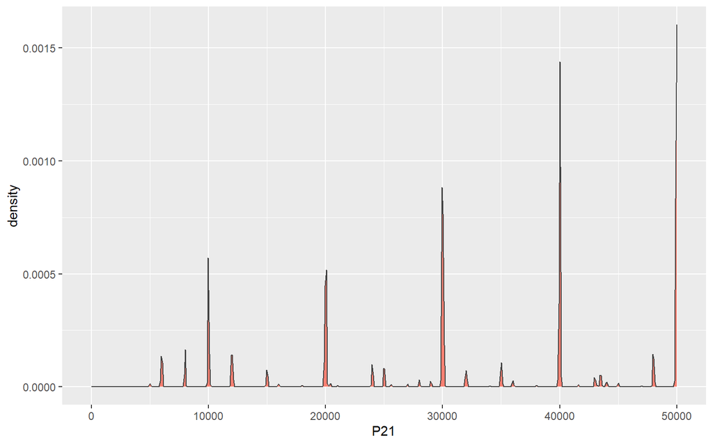

```r
ggplot(base_para_otros_ejemplos, aes(x = P21,weights = PONDIIO))+
geom_density(adjust = 0.01,fill='salmon', color='grey25')+
scale_x_continuous(limits = c(0,50000))
```

#### Geom Smooth

Para realizar estos gráficos, vamos a modificar un poco los datos:

- filtramos los ingresos iguales a 0.
- eliminamos las no respuestas de nivel educativo y las personas con educación especial.
- eliminamos las respuestas de tipo de establecimiento = ‘otros’.
- recodificamos las variables para que tengan nombres más sugestivos:
  - **Nivel educativo** además la convertimos a factor, porque queremos explicitarle el orden de los valores con `levels()`. El “\n”” es un *caracter especial* que permite que el string continúe en la siguiente línea.
  - Sexo.
  - Tipo de establecimiento.

```r
ggdata <- base_para_otros_ejemplos %>%
  filter(!is.na(NIVEL_ED),
         NIVEL_ED!=7,
         PP04A !=3) %>%
  mutate(NIVEL_ED = factor(case_when(NIVEL_ED == 1  ~ 'Primaria \n Incompleta', # '\n' significa carriage return, o enter
                                     NIVEL_ED == 2  ~ 'Primaria \n Completa',
                                     NIVEL_ED == 3  ~ 'Secundaria \nIncompleta',
                                     NIVEL_ED == 4  ~ 'Secundaria \nCompleta',
                                     NIVEL_ED == 5  ~ 'Superior \nUniversitaria \nIncompleta',
                                     NIVEL_ED == 6  ~ 'Superior \nUniversitaria \nCompleta',
                                     FALSE          ~ 'Otro'),
                           levels= c('Primaria \n Incompleta',
                                     'Primaria \n Completa',
                                     'Secundaria \nIncompleta',
                                     'Secundaria \nCompleta',
                                     'Superior \nUniversitaria \nIncompleta',
                                     'Superior \nUniversitaria \nCompleta')),
         Sexo     = case_when(CH04 == 1 ~ 'Varón',
                              CH04 == 2 ~ 'Mujer'),
         Establecimiento    = case_when(PP04A == 1 ~ 'Estatal',
                                        PP04A == 2 ~ 'Privado',
                                        FALSE      ~ 'Otro'))

ggdata
```

[output not shown]

[output cut: 10932 more lines]

Para graficar un suavizado de las series, se utiliza la función [`geom_smooth()`](http://ggplot2.tidyverse.org/reference/geom_smooth.html). Con suavizado nos referimos al gráfico de un modelo realizado sobre los datos, que estima el valor en el punto x,y (para el grupo). Las regresiones lineales son un ejemplo de esto, aunque no el único, ni el que viene por default.

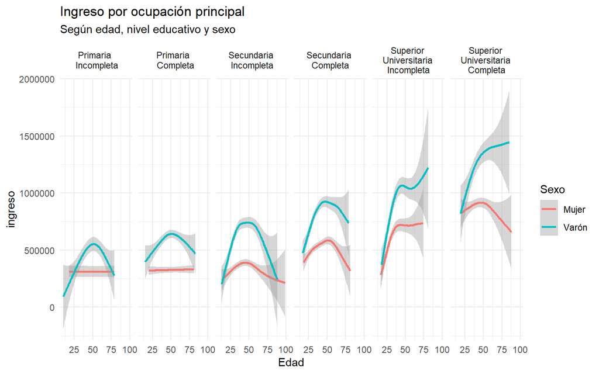

```r
ggplot(ggdata, aes(CH06, P21, colour = Sexo, shape = Sexo, alpha = P21))+
  geom_smooth() +
  labs(
    x = 'Edad',
    y = 'ingreso',
    title = 'Ingreso por ocupación principal',
    subtitle = 'Según edad, nivel educativo y sexo') +
  theme_minimal()+
  scale_y_continuous()+
  scale_alpha(guide = FALSE)+
  facet_grid(~NIVEL_ED)
```

Si corremos el comando `geom_smooth()` por default, nos advierte que esta utilizando el método GAM, de [general additive models](https://m-clark.github.io/generalized-additive-models/building_gam.html).

el **sombreado gris** que envuelve cada línea es el intervalo de confianza de dicho punto (95% por default).

También podemos utilizar métodos lineales, agregando el parámetro `method = 'lm'`. Haciendo esto, el gráfico muestra una regresión lineal simple. Si queremos otro tipo de regresión lineal, le podemos explicitar la fórmula.  
En el ejemplo siguiente, utilizamos la formula $y = \beta_0 +\beta_1x +\beta_2 x^2$.

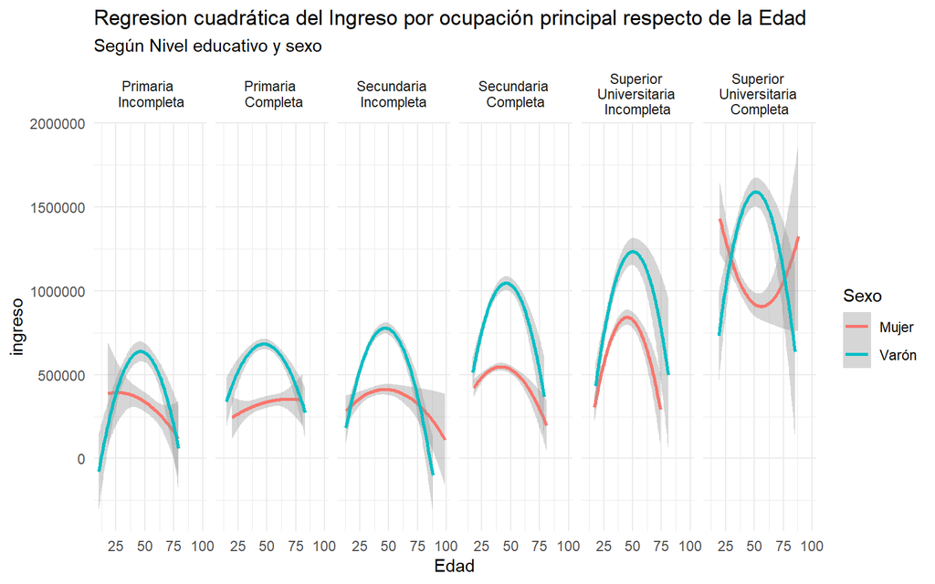

```r
ggplot(ggdata, aes(CH06, P21, colour = Sexo, weight = PONDIIO)) +
  geom_smooth(method = "lm", formula = y ~ poly(x, 2)) +
  labs(x = 'Edad',
       y = 'ingreso',
       title = 'Regresion cuadrática del Ingreso por ocupación principal respecto de la Edad',
       subtitle = 'Según Nivel educativo y sexo') +
  theme_minimal()+
  facet_grid( ~ NIVEL_ED)
```

Si quisiéramos, además de ver la relación entre ingreso, Edad, Sexo y Nivel educativo, incorporar el tipo de establecimiento,público o privado. Podemos facetear el gráfico por dos variables en lugar de una, lo que crea una **matriz de gráficos** según los cruces.

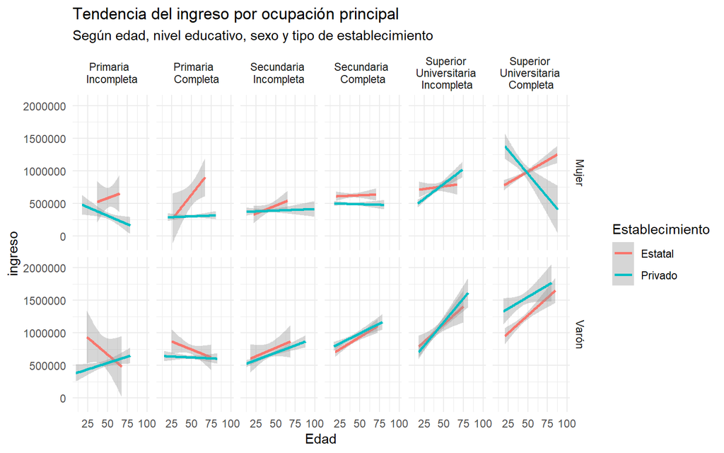

```r
ggplot(ggdata, aes(CH06, P21, colour = Establecimiento, weight = PONDIIO)) +
  geom_smooth(method = "lm") +
  labs(
  x = 'Edad',
  y = 'ingreso',
  title = 'Tendencia del ingreso por ocupación principal',
  subtitle = 'Según edad, nivel educativo, sexo y tipo de establecimiento') +
  theme_minimal()+
  facet_grid(Sexo ~ NIVEL_ED)
```

### Distribución de los ingresos laborales y no laborales por sexo

- Ingresos no laborales : *TVI*
- Ingreso laborales:
  - *P21* MONTO DE INGRESO DE LA OCUPACIÓN PRINCIPAL
  - *Totp12* MONTO DE INGRESO DE OTRAS OCUPACIONES.

```r
  datagraf_2 <-individual_25_t1 %>%
  ##eligo las variables que necesito
    select(P47T,T_VI, TOT_P12, P21 , PONDII, CH04,NIVEL_ED) %>%
  ## Me quedo con los que tienen ingreso total individual (P47) positivo
    filter(!is.na(P47T), P47T > 0 ) %>%
    mutate(ingreso_laboral    = TOT_P12 + P21,
           ingreso_no_laboral = T_VI,
           ingreso_total      = ingreso_laboral + ingreso_no_laboral,
           CH04               = case_when(CH04 == 1 ~ "Varon",
                                          CH04 == 2 ~ "Mujer")) %>%
  group_by(CH04) %>%
  summarise('ingreso laboral'    = sum(ingreso_laboral*PONDII)/sum(ingreso_total*PONDII),
            'ingreso no laboral' = sum(ingreso_no_laboral*PONDII)/sum(ingreso_total*PONDII))

datagraf_2
```

```
# A tibble: 2 × 3
  CH04  `ingreso laboral` `ingreso no laboral`
  <chr>             <dbl>                <dbl>
1 Mujer                NA                   NA
2 Varon                NA                   NA
```

Doy vuelta la tabla para poder graficar

```r
datagrafico <- datagraf_2 %>%
gather(tipo_ingreso, monto,2:3 )
datagrafico
```

```
# A tibble: 4 × 3
  CH04  tipo_ingreso       monto
  <chr> <chr>              <dbl>
1 Mujer ingreso laboral       NA
2 Varon ingreso laboral       NA
3 Mujer ingreso no laboral    NA
4 Varon ingreso no laboral    NA
```

[figure not shown]

```r
ggplot(datagrafico, aes(CH04, monto, fill = tipo_ingreso,
                      label = sprintf("%1.1f%%", 100*monto)))+
  geom_col(position = "stack", alpha=0.6) +
  geom_text(position = position_stack(vjust = 0.5), size=5)+
  labs(x="",y="Porcentaje")+
  theme_tufte()+
  scale_y_continuous()+
  theme(legend.position = "bottom",
        legend.title=element_blank(),
        axis.text.x = element_text(angle=25))
```

Podemos agregar también grupos de edad como otra dimensión del análisis. Optamos por restringuir la población de análisis a la comprendida entre 18 y 60 años

```r
####Agrego al procedimiento anterior una clasificación de las edades
  datagraf_3 <-individual_25_t1 %>%
    select(P47T,T_VI, TOT_P12, P21 , PONDII, CH04,CH06) %>%
    filter(!is.na(P47T), P47T > 0 , CH06 %in% c(18:60)) %>%
    mutate(ingreso_laboral    = as.numeric(TOT_P12 + P21),
           ingreso_no_laboral = as.numeric(T_VI),
           ingreso_total      = ingreso_laboral + ingreso_no_laboral,
           CH04               = case_when(CH04 == 1 ~ "Varon",
                                          CH04 == 2 ~ "Mujer"),
           EDAD = case_when(CH06 %in% c(18:30) ~ "18 a 30",      ##<<
                            CH06 %in% c(31:45) ~"31 a 45",       ##<<
                            CH06 %in% c(46:60) ~ "46 a 60")) %>% ##<<
  group_by(CH04,EDAD) %>%                                        ##<<
  summarise('ingreso laboral'    = sum(ingreso_laboral*PONDII)/sum(ingreso_total*PONDII),
            'ingreso no laboral' = sum(ingreso_no_laboral*PONDII)/sum(ingreso_total*PONDII)) %>%
gather(tipo_ingreso, monto,3:4)

datagraf_3
```

```
# A tibble: 12 × 4
# Groups:   CH04 [2]
   CH04  EDAD    tipo_ingreso        monto
   <chr> <chr>   <chr>               <dbl>
 1 Mujer 18 a 30 ingreso laboral    0.816
 2 Mujer 31 a 45 ingreso laboral    0.849
 3 Mujer 46 a 60 ingreso laboral    0.819
 4 Varon 18 a 30 ingreso laboral    0.942
 5 Varon 31 a 45 ingreso laboral    0.958
 6 Varon 46 a 60 ingreso laboral    0.908
 7 Mujer 18 a 30 ingreso no laboral 0.184
 8 Mujer 31 a 45 ingreso no laboral 0.151
 9 Mujer 46 a 60 ingreso no laboral 0.181
10 Varon 18 a 30 ingreso no laboral 0.0583
11 Varon 31 a 45 ingreso no laboral 0.0420
12 Varon 46 a 60 ingreso no laboral 0.0916
```

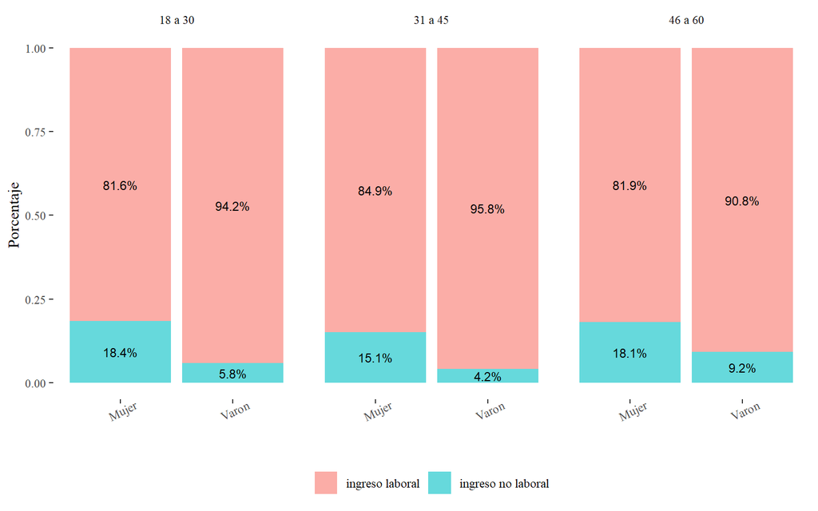

```r
ggplot(datagraf_3, aes(CH04, monto, fill = tipo_ingreso,
                      label = sprintf("%1.1f%%", 100*monto)))+
  geom_col(position = "stack", alpha=0.6) +
  geom_text(position = position_stack(vjust = 0.5), size=3)+
  labs(x="",y="Porcentaje")+
  theme_tufte()+
  scale_y_continuous()+
  theme(legend.position = "bottom",
        legend.title=element_blank(),
        axis.text.x = element_text(angle=25))+
  facet_wrap(~EDAD)
```

En los gráficos utilizamos extensiones de ggplot:

simplemente debemos recordar cargar las librerías si queremos utilizar esas funciones.

### Otros gráficos

Los gráficos hasta aquí realizados (barras, línea) son fácilmente reproducibles en un excel ya que utilizan la información agregada. Sin embargo, la gran ventaja del **R** se manifiesta a a la hora de realizar:

- Gráficos que necesitan la información a nivel de microdatos. **puntos**, **boxplots**, **Kernels**, etc.
- Abrir un mismo gráfico según alguna variable discreta: `facet_wrap()`
- Parametrizar otras variables, para aumentar la dimensionalidad del gráficos.
  - [**color**](http://www.stat.columbia.edu/~tzheng/files/Rcolor.pdf) `color =`
  - **relleno**`fill =`
  - **forma** `shape =`
  - **tamaño** `size =`
  - **transparencia** `alpha =`

Esto permite tener, en el plano, gráficos de muchas dimensiones de análisis

- Si el color representa una variable lo definimos **dentro del aes()**, `aes(... color = ingresos)`
- Cuando queremos simplemente mejorar el diseño (es fijo), se asigna por fuera, o dentro de cada tipo de gráficos, `geom_col(color = 'green')`.

#### [**Boxplots**](https://flowingdata.com/2008/02/15/how-to-read-and-use-a-box-and-whisker-plot/)

- Los gráficos Boxplot representan una única variable (univariados).
- Están compuestos por una caja, cuyo límite inferior es el valor donde se alcanza el 25% de la distribución
- Su límite superior es el valor donde se alcanza el 75% de la misma.
- A su vez, también el gráfico marca los valores “outliers” (datos que se encuentran a una distancia de al menos 1,5 veces el tamaño de la caja del límite inferior o superior de la caja, según corresponda)

Boxplot de ingresos de la ocupación principal, según nivel educativo

Hacemos un procesamiento simple: Sacamos los ingresos iguales a cero y las no respuestas de nivel educativo.  
Es importante que las variables sean del tipo que conceptualmente les corresponde (el nivel educativo es una variable categórica, no continua), para que el ggplot pueda graficarlo correctamente.

```r
## Las variables sexo( CH04 ) y Nivel educativo están codificadas como números, y el R las entiende como numéricas.
class(individual_25_t1$NIVEL_ED)
```

```
[1] "integer"
```

```r
class(individual_25_t1$CH04)
```

```
[1] "integer"
```

```r
ggdata <- individual_25_t1 %>%
  filter(P21>0, !is.na(NIVEL_ED)) %>%
  mutate(NIVEL_ED = as.factor(NIVEL_ED),
         CH04     = as.factor(CH04))
```

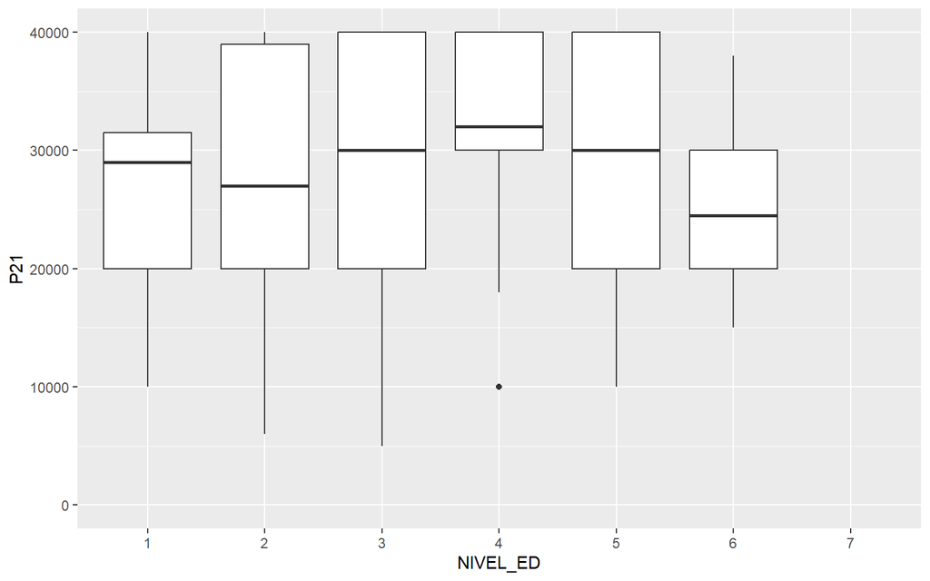

```r
ggplot(ggdata, aes(x = NIVEL_ED, y = P21)) +
  geom_boxplot()+
  scale_y_continuous(limits = c(0, 40000))##Restrinjo el gráfico hasta ingresos de $40000
```

Si queremos agregar la dimensión *sexo*, podemos hacer un `facet_wrap()`

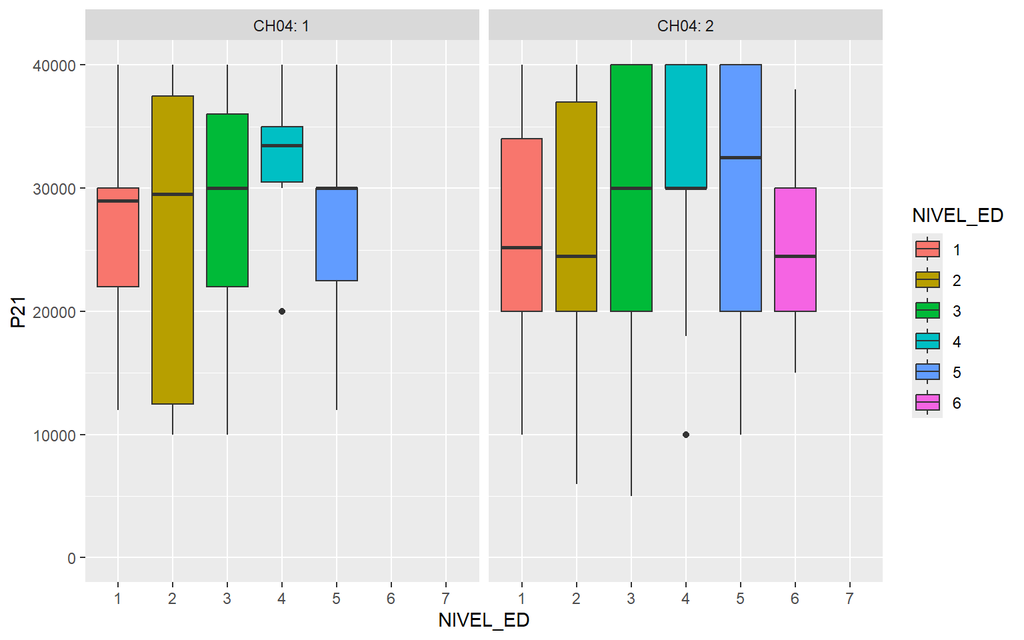

```r
ggplot(ggdata, aes(x= NIVEL_ED, y = P21, group = NIVEL_ED, fill = NIVEL_ED )) +
  geom_boxplot()+
  scale_y_continuous(limits = c(0, 40000))+
  facet_wrap(~ CH04, labeller = "label_both")
```

Por la forma en que está presentado el gráfico, el foco de atención sigue puesto en las diferencias de ingresos entre niveles educativo. Simplemente se agrega un corte por la variable de sexo.

Si lo que queremos hacer es poner el foco de atención en las diferencias por sexo, simplemente basta con invertir la variable x especificada con la variable utilizada en el `facet_wrap`

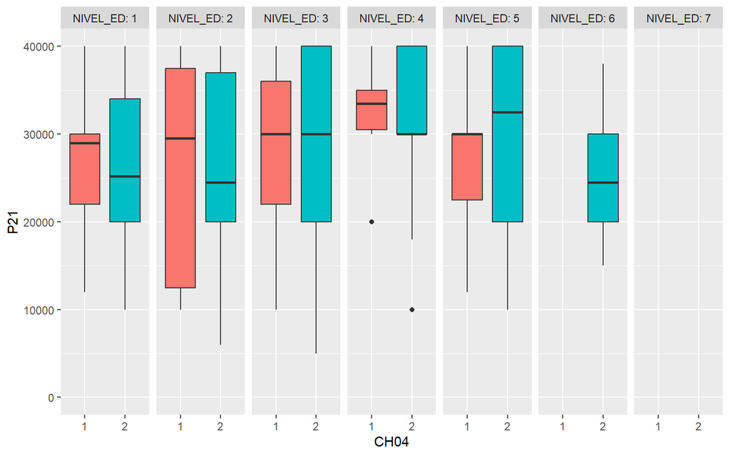

```r
ggplot(ggdata, aes(x= CH04, y = P21, group = CH04, fill = CH04 )) +
  geom_boxplot()+
  scale_y_continuous(limits = c(0, 40000))+
  facet_grid(~ NIVEL_ED, labeller = "label_both") +
  theme(legend.position = "none")
```

#### [Histogramas](https://ggplot2.tidyverse.org/reference/geom_histogram.html)

Otra forma de mostrar la distribución de una variable es utilizar un histograma. Este tipo de gráficos agrupa las observaciones en **bins**: intervalos dentro del rango de la variable. Luego cuenta la cantidad de observaciones que caen dentro de cada uno de estos bins.

Por ejemplo, si observamos el ingreso de la ocupación principal:

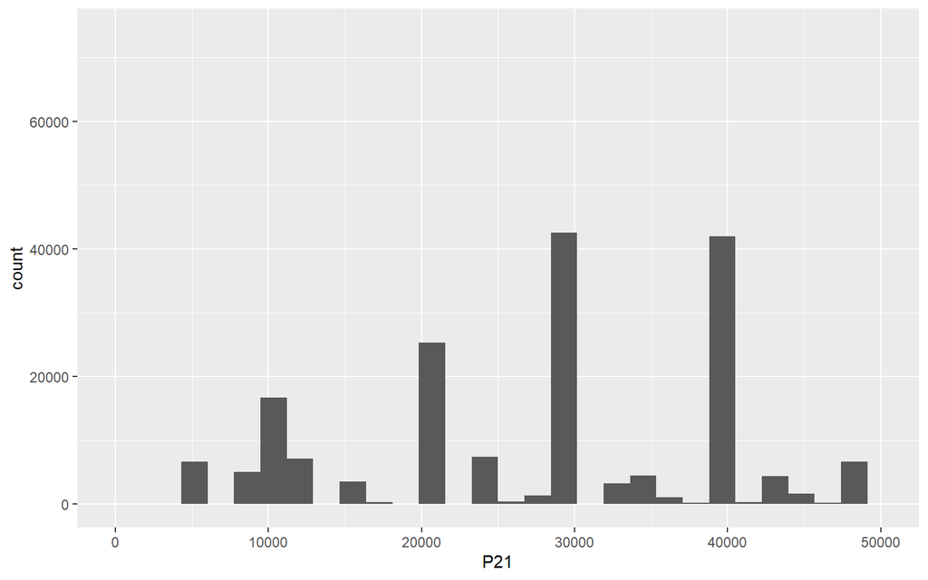

```r
hist_data <-individual_25_t1 %>%
  filter(P21>0)

ggplot(hist_data, aes(x = P21,weights = PONDIIO))+
geom_histogram()+
scale_x_continuous(limits = c(0,50000))
```

En este gráfico, los posibles valores de p21 se dividen en 30 **bins** consecutivos y el gráfico muestra cuantas observaciones caen en cada uno de ellos

#### [Kernels](https://plot.ly/ggplot2/geom_density/)

La función `geom_density()` nos permite construir **kernels** de la distribución. Esto es, un suavizado sobre los histogramas que se basa en alguna distribución supuesta dentro de cada bin. Es particularmente útil cuando tenemos una variable continua, dado que los histogramas rompen esa sensación de continuidad.

Veamos un ejemplo sencillo con los ingresos de la ocupación principal. Luego iremos complejizandolo

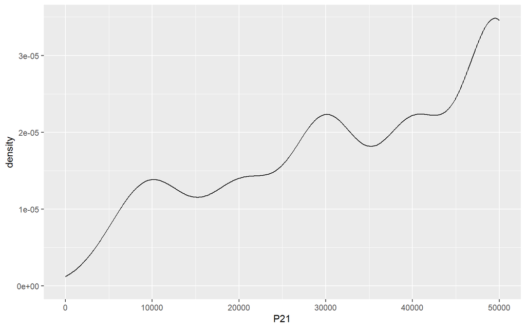

```r
kernel_data <-individual_25_t1 %>%
  filter(P21>0)

ggplot(kernel_data, aes(x = P21,weights = PONDIIO))+
geom_density()+
scale_x_continuous(limits = c(0,50000))
```

**El eje y no tiene demasiada interpretabilidad en los Kernel, porque hace a la forma en que se construyen las distribuciones**.

El parametro adjust, dentro de la función `geom_density`nos permite reducir o ampliar el rango de suavizado de la distribución. Su valor por default es 1. Veamos que sucede si lo seteamos en 2

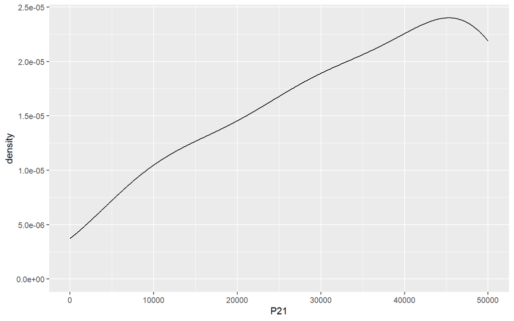

```r
ggplot(kernel_data, aes(x = P21,weights = PONDIIO))+
geom_density(adjust = 2)+
scale_x_continuous(limits = c(0,50000))
```

Como es esperable, la distribución del ingreso tiene “picos” en los valores redondos, ya que la gente suele declarar un valor aproximado al ingreso efectivo que percibe. Nadie declara ingresos de 30001. Al suavizar la serie con un kernel, eliminamos ese efecto.Si seteamos el rango para el suavizado en valores menores a 1, podemos observar estos picos.

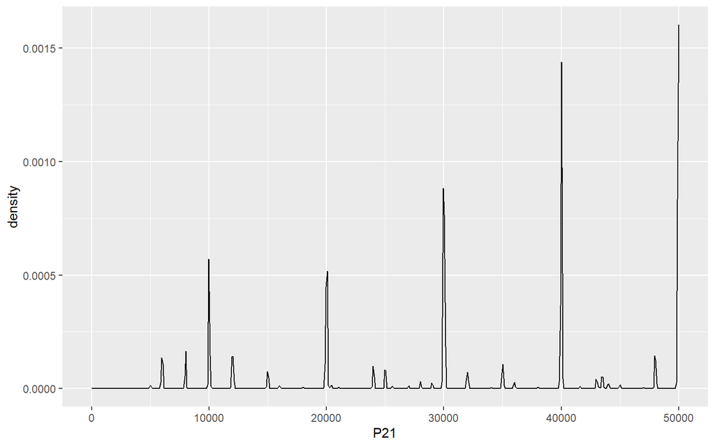

```r
ggplot(kernel_data, aes(x = P21,weights = PONDIIO))+
geom_density(adjust = 0.01)+
scale_x_continuous(limits = c(0,50000))
```

Ahora bien, como en todo grafico de R, podemos seguir agregando dimensiones para enriquecer el análisis.

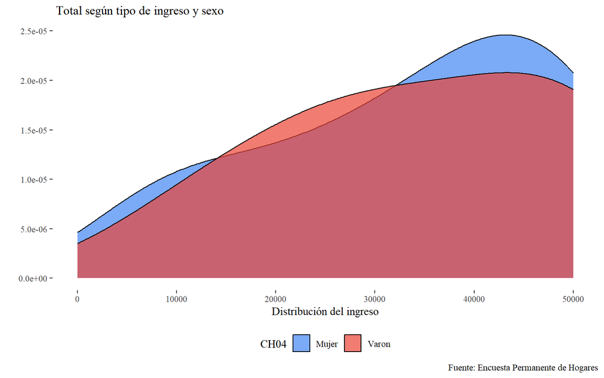

```r
kernel_data_2 <- kernel_data %>%
  mutate(CH04= case_when(CH04 == 1 ~ "Varon",
                         CH04 == 2 ~ "Mujer"))

ggplot(kernel_data_2, aes(x = P21,
  weights = PONDIIO,
  group = CH04,
  fill = CH04)) +
  geom_density(alpha=0.7,adjust =2)+
  labs(x="Distribución del ingreso", y="",
       title=" Total según tipo de ingreso y sexo",
       caption = "Fuente: Encuesta Permanente de Hogares")+
  scale_x_continuous(limits = c(0,50000))+
  theme_tufte()+
  scale_fill_gdocs()+
  theme(legend.position = "bottom",
        plot.title      = element_text(size=12))
```

Podemos agregar aún la dimensión de ingreso laboral respecto del no laboral

```r
kernel_data_3 <-kernel_data_2 %>%
  select(REGION,P47T,T_VI, TOT_P12, P21 , PONDII, CH04) %>%
  filter(!is.na(P47T), P47T > 0 ) %>%
  mutate(ingreso_laboral    = TOT_P12 + P21,
         ingreso_no_laboral = T_VI) %>%
  gather(., key = Tipo_ingreso, Ingreso, c((ncol(.)-1):ncol(.))) %>%
  filter( Ingreso !=0)## Para este gráfico, quiero eliminar los ingresos = 0

kernel_data_3[1:10,]
```

```
   REGION   P47T   T_VI TOT_P12    P21 PONDII  CH04    Tipo_ingreso Ingreso
1      43 628000 428000       0 200000   1140 Mujer ingreso_laboral  200000
2      43 690000 290000       0 400000   1765 Mujer ingreso_laboral  400000
3      43 800000      0       0 800000    894 Mujer ingreso_laboral  800000
4      43 250000      0       0 250000    960 Varon ingreso_laboral  250000
5      43 699000  49000       0 650000    775 Mujer ingreso_laboral  650000
6      41 800000      0       0 800000    766 Varon ingreso_laboral  800000
7      41 350000      0       0 350000    348 Varon ingreso_laboral  350000
8      40 450000      0  300000 150000    200 Mujer ingreso_laboral  450000
9      40 360000      0  300000  60000    200 Mujer ingreso_laboral  360000
10     40 120000      0       0 120000    184 Mujer ingreso_laboral  120000
```

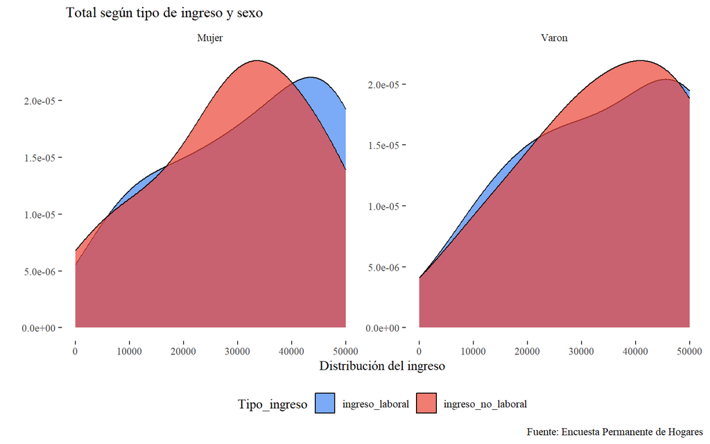

```r
  ggplot(kernel_data_3, aes(
  x = Ingreso,
  weights = PONDII,
  group = Tipo_ingreso,
  fill = Tipo_ingreso)) +
  geom_density(alpha=0.7,adjust =2)+
  labs(x="Distribución del ingreso", y="",
       title=" Total según tipo de ingreso y sexo",
       caption = "Fuente: Encuesta Permanente de Hogares")+
  scale_x_continuous(limits = c(0,50000))+
  theme_tufte()+
  scale_fill_gdocs()+
  theme(legend.position = "bottom",
        plot.title      = element_text(size=12))+
  facet_wrap(~ CH04, scales = "free")
```

En este tipo de gráficos, importa mucho qué variable se utiliza para *facetear* y qué variable para agrupar, ya que la construcción de la distribución es diferente.

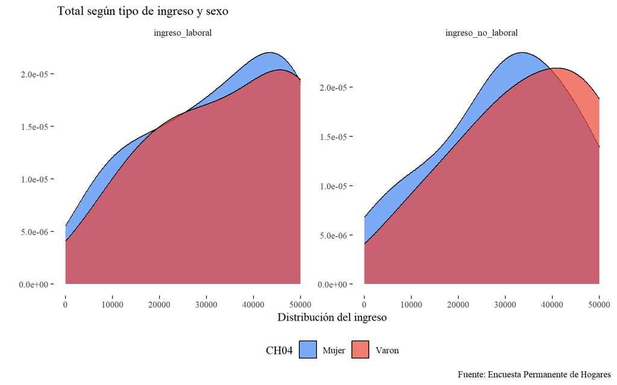

```r
ggplot(kernel_data_3, aes(
  x = Ingreso,
  weights = PONDII,
  group = CH04,
  fill = CH04)) +
  geom_density(alpha=0.7,adjust =2)+
  labs(x="Distribución del ingreso", y="",
       title=" Total según tipo de ingreso y sexo",
       caption = "Fuente: Encuesta Permanente de Hogares")+
  scale_x_continuous(limits = c(0,50000))+
  theme_tufte()+
  scale_fill_gdocs()+
  theme(legend.position = "bottom",
        plot.title      = element_text(size=12))+
  facet_wrap(~Tipo_ingreso, scales = "free")
```

## Ejercicios

### Para practicar

- Calcular el promedio del ingreso por ocupación principal (Variable **P21**) para **asalariados** con y sin **descuento jubilatorio** (Variable **PP07H**). Luego realizar un gráfico de barras donde se comparen ambos valores (para el 1er trimestre de 2025).  
  Pistas: Se deben filtrar previamente los ingresos mayores a 0 (**P21>0**).Chequear que ponderador corresponde utilizar
- Graficar la distribución del ingreso por ocupación principal para Asalariados, Cuentapropistas y Patrones, con el tipo de gráfico Kernel  
  Pista: Usar la función **facet_wrap** para separar a cada una de las categorías ocupacionales)  
  Sugerencia: incorporar la línea `scale_x_continuous(limits = c(0,1000000))` entre las capas del gráfico. ¿Qué cambió?

### De tarea

- Hacer un gráfico boxplot de la distribución de edades de los asalariados con descuento jubilatorio, y de los asalariados sin descuento jubilatorio.
- Uniendo las bases de los distintos trimestres, calcular el procentaje de asalariados sin descuento jubilatorio como $\frac{Asal. s/ desc jubil}{Asal. c/ desc jubil+ Asal.s/ desc jubil}$. Luego realizar un gráfico de linea con la evolución de este indicador

## Bibliografía

Wickham, H., & Grolemund, G. (2023). *R for Data Science (2nd ed)*. O'Reilly Media.

Tidyverse. (2023, April). *Base vs. magrittr pipe*. Recuperado de https://www.tidyverse.org/blog/2023/04/base-vs-magrittr-pipe/

DataViz Inspiration. (n.d.). RetrievedRecuperado de https://www.dataviz-inspiration.com/

[Seminario "Estadística y programación para estudios del trabajo, desigualdad y pobreza". Doctorado en Ciencias Sociales](https://www.sociales.uba.ar/posgrados/doctorado/)

*guidowe45@gmail.com*